# Credit Risk Modeling

Jordan Kassof

December 21, 2015

Today I want to explore a classic classification problem (apologies for the accidental phone) encountered in business; credit ratings/approvals. In particular we will be looking to classify the quality of a loan prospect (good/bad) given a set of attributes about the loan and the applicant. We will be using the German Credit data set that comes with the `caret` package.

First let’s load up our data get a grip on what we are looking at.

```r
library(caret); data("GermanCredit")
```

Below is an excerpt from the UCI Machine Learning Repository about this particular data set.

> Data from Dr. Hans Hofmann of the University of Hamburg.

> These data have two classes for the credit worthiness: good or bad. There are predictors related to attributes, such as: checking account status, duration, credit history, purpose of the loan, amount of the loan, savings accounts or bonds, employment duration, Installment rate in percentage of disposable income, personal information, other debtors/guarantors, residence duration, property, age, other installment plans, housing, number of existing credits, job information, Number of people being liable to provide maintenance for, telephone, and foreign worker status.

This is a very important task in the financial services industry; understanding the risk in a loan portfolio is crucial to any lender’s business model. Bad credit masquerading as good credit was one of the key drivers of the 2008 financial crisis.

# Exploratory Data Analysis

Getting a general feel for the relationships represented by a data set is a crucial first step in modeling. Looking at our list of variables, Age seems like as good a place as ever to start looks. Let’s see what the age distribution of Good and Bad loans look like.

Below code produces a nice little ggplot visualization of the Age (of applicant), Duration (of loan) and Amount (of loan) broken out by the classification of the loan.

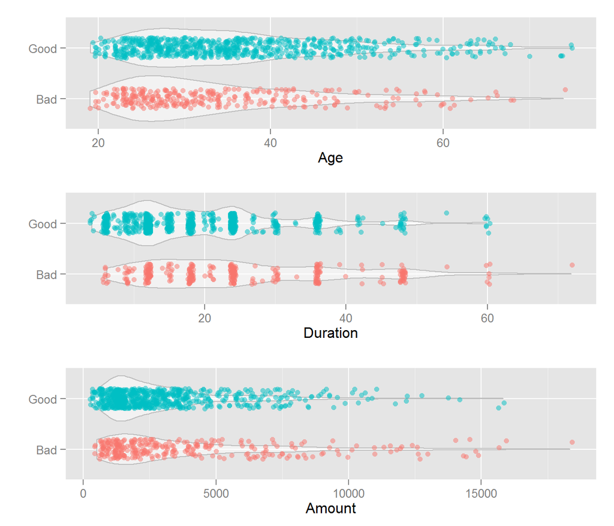

```r
library(gridExtra)
g1 <- ggplot(GermanCredit, aes(x = Class, y  = Age)) +
  geom_violin(alpha = 0.5, color = "gray") +
  geom_jitter(alpha = 0.5, aes(color = Class), position = position_jitter(width = .2)) +
  coord_flip() +
  labs(x ="")  +
  theme(legend.position="none")

g2 <- ggplot(GermanCredit, aes(x = Class, y  = Duration)) +
  geom_violin(alpha = 0.5, color = "gray") +
  geom_jitter(alpha = 0.5, aes(color = Class), position = position_jitter(width = .2)) +
  coord_flip() +
  labs(x ="") +
  theme(legend.position="none")

g3 <- ggplot(GermanCredit, aes(x = Class, y  = Amount)) +
  geom_violin(alpha = 0.5, color = "gray") +
  geom_jitter(alpha = 0.5, aes(color = Class), position = position_jitter(width = .2)) +
  coord_flip() +
  labs(x ="") +
  theme(legend.position="none")

grid.arrange(g1, g2, g3, nrow = 3)
```

We can see that Bad loans appear to have a higher proportion of young applicants relative to Good loans. This isn’t too surprising, we would expect older Applicants to be lower risk as they presumably have had more time to prepare financially and logistically to take on a line of credit.

# Modeling

In this section of our exploration I will be developing a number of models to predict the class of a loan. I will utilize various algorithms and R package implementations but in the end I will attempt to quantitatively measure how each performs.

An important first step of any data modeling project is establishing training and testing data. We build our models on our training data, totally blind to the testing set. Once we are satisfied with our performance on our training data we can apply the model to the testing set to get an idea for the out-of-sample performance of our model. This is a crucial step to check for over-fitting models to the training data.

Below we split our data into 60% training and 40% testing.

```r
set.seed(65897)
inTrain <- createDataPartition(GermanCredit$Class, p = 0.6, list = FALSE)
training <- GermanCredit[inTrain,]
testing <- GermanCredit[-inTrain,]
```

## CART Modeling

Classification and Regression Tree (CART) modeling is a popular standard because the results are easy to visualize and interpret and it is very inexpensive (computationally and thus economically) to make future predictions. Below I will grow a basic decision tree

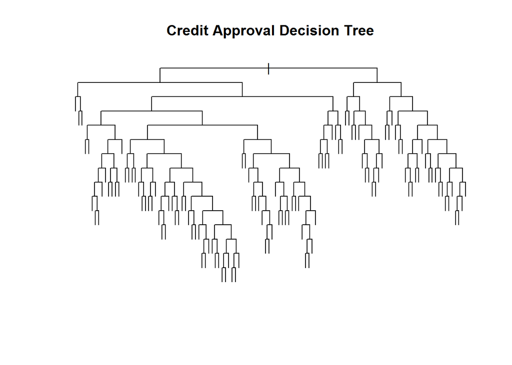

```r
set.seed(1223); library(rpart)
rpart.fit <- rpart(Class ~ ., data = training,
                   method = 'class',
                   minsplit = 0,
                   cp = 0) # grow tree
plot(rpart.fit, uniform = TRUE, main = 'Credit Approval Decision Tree') # plot tree
```

The details of the splits for the above tree are left out intentionally. The number of splits all but guarantees an over-fit model. Part of the benefit of trees is their ease of interpretability…and the above is a total mess.

For this reason I am going to prune the tree by using a complexity factor that minimizes the cross-validation error. The complexity factor is one of the “knobs” that a data scientist has at their disposal to tweak how the CART model comes out.

The below code plots the effect of the complexity factor on relative error. Then we prune the tree using the complexity factor that minimizes error. Next we will plot the pruned tree and create a confusion matrix to compare look at the predictions our model comes up with for the test data.

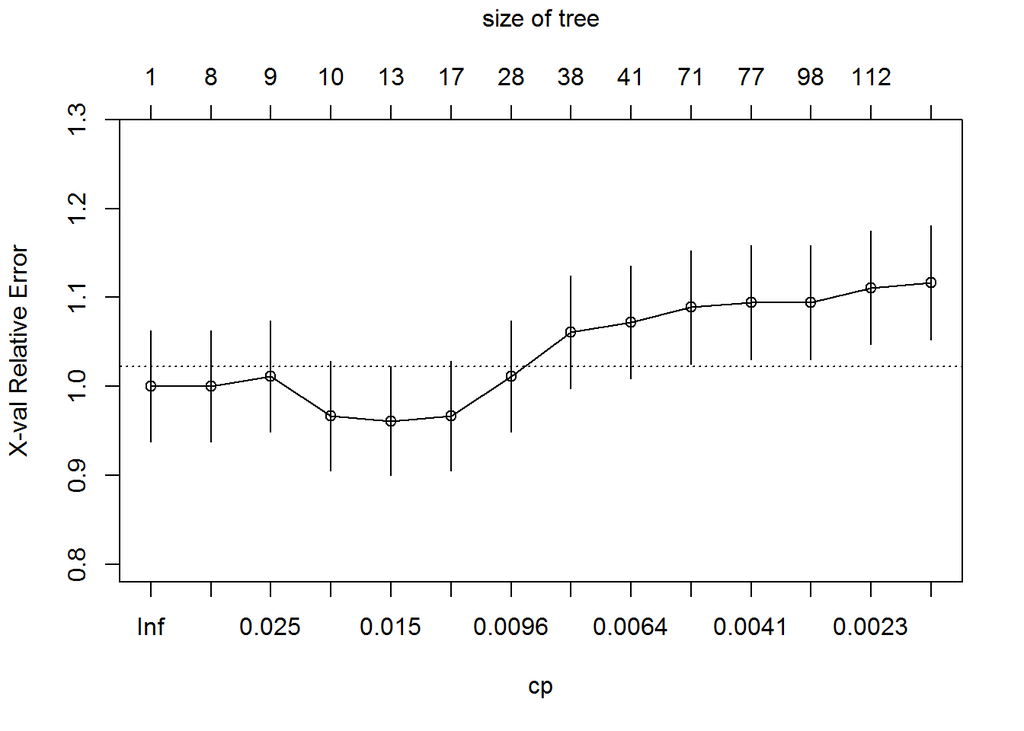

```r
rpart::plotcp(rpart.fit)
```

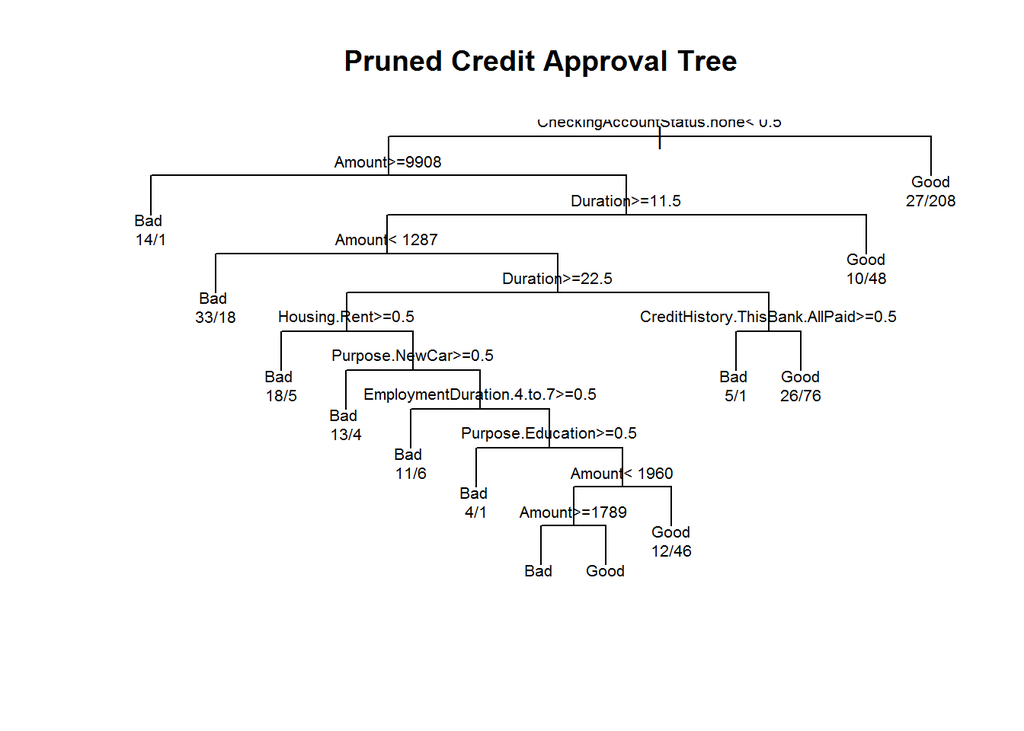

```r
pruned.rpart <- rpart::prune(rpart.fit, cp =
                        rpart.fit$cptable[which.min(rpart.fit$cptable[, "xerror"]), "CP"])

plot(pruned.rpart, uniform = TRUE, main = 'Pruned Credit Approval Tree')
text(pruned.rpart, cex = .65, use.n = TRUE)
```

```r
confusionMatrix(predict(pruned.rpart, newdata = testing, type = 'class'), testing$Class)
```

```
## Confusion Matrix and Statistics
##
##           Reference
## Prediction Bad Good
##       Bad   46   48
##       Good  74  232
##
##                Accuracy : 0.695
##                  95% CI : (0.6473, 0.7398)
##     No Information Rate : 0.7
##     P-Value [Acc > NIR] : 0.61005
##
##                   Kappa : 0.2259
##  Mcnemar's Test P-Value : 0.02361
##
##             Sensitivity : 0.3833
##             Specificity : 0.8286
##          Pos Pred Value : 0.4894
##          Neg Pred Value : 0.7582
##              Prevalence : 0.3000
##          Detection Rate : 0.1150
##    Detection Prevalence : 0.2350
##       Balanced Accuracy : 0.6060
##
##        'Positive' Class : Bad
##
```

So we can see we have a 69.5% accuracy, but accuracy is not always the most relevant or important statistical measure. There are a number of measures related to binary classification, all of which have their time to shine pending on the field! A succinct table describing the various measurements is below.

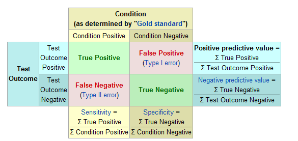

## Conditional Inference Trees

Conditional inference trees are another example of recursive partitioning. Utilizing a clever statistical approach, CI Trees have slightly different nodes than regular decision trees and they provide distributional properties at the end of each branch.

```r
set.seed(1223); library(party)
```

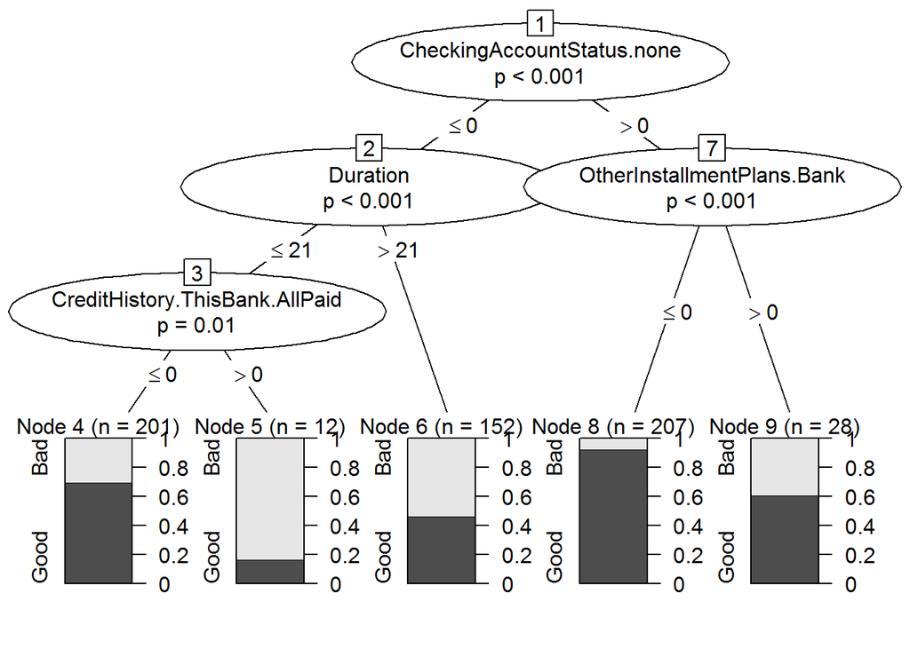

```r
cfit <- ctree(Class ~ ., data = training)
plot(cfit, cex = .8)
```

## Random Forests

Another option for classification modeling is the random forest.

Random Forest algorithms have risen to become major players in predictive analytics and are a natural extension of decision trees. Random forests ameliorate decision tree’s over-fitting problem by growing many decision trees, each with a random subset of the available features. The random forest then takes the mode of all the predictions to come up with a final prediction.

Below is a basic random forest implementation which uses 10 time repeated 10-fold cross-validation. Cross-validation is another method of reducing over-fitting. There are a number of “knobs” which can be tweaked on the random forest algorithm, but for brevity’s sake, the below is untweaked.

```r
fitControl <- trainControl(method = "repeatedcv",
                           number = 10,
                           repeats = 10)

rf.fit <- train(Class ~ ., data = training,
                 method = "rf",
                 trControl = fitControl)
```

```r
confusionMatrix(predict(rf.fit, newdata = testing), testing$Class)
```

```
## Confusion Matrix and Statistics
##
##           Reference
## Prediction Bad Good
##       Bad   50   35
##       Good  70  245
##
##                Accuracy : 0.7375
##                  95% CI : (0.6915, 0.78)
##     No Information Rate : 0.7
##     P-Value [Acc > NIR] : 0.0554674
##
##                   Kappa : 0.3182
##  Mcnemar's Test P-Value : 0.0009064
##
##             Sensitivity : 0.4167
##             Specificity : 0.8750
##          Pos Pred Value : 0.5882
##          Neg Pred Value : 0.7778
##              Prevalence : 0.3000
##          Detection Rate : 0.1250
##    Detection Prevalence : 0.2125
##       Balanced Accuracy : 0.6458
##
##        'Positive' Class : Bad
##
```

As we can see, the confusion matrix and statistics for our Random Forest are generally better than the single decision tree from earlier. A very useful feature of random forest modeling is that you can easily identify the most important variables. There are regulations that can require a lender to provide the specific reasons an applicant was turned down in certain situations. Let’s see what our random forest shows.

```r
varImp(rf.fit)
```

```
## rf variable importance
##
##   only 20 most important variables shown (out of 61)
##
##                                Overall
## Amount                         100.000
## Duration                        62.292
## Age                             58.945
## CheckingAccountStatus.none      58.504
## CheckingAccountStatus.lt.0      22.150
## InstallmentRatePercentage       19.455
## ResidenceDuration               18.048
## CreditHistory.Critical          17.448
## OtherInstallmentPlans.Bank      11.788
## SavingsAccountBonds.lt.100      11.718
## CreditHistory.ThisBank.AllPaid  11.611
## Housing.Own                     11.563
## NumberExistingCredits           11.216
## Purpose.NewCar                  10.866
## Purpose.Furniture.Equipment     10.858
## Purpose.Business                10.067
## Housing.Rent                     9.837
## Property.Insurance               9.677
## Property.CarOther                9.557
## SavingsAccountBonds.Unknown      9.296
```

The factors with the most influence in our model are the amount of the loan, the duration of the payback period, the age of the requester, the checking account status, and credit history. These are all pretty intuitive factors that play into credit decisions. This is a bit of a double-edged sword. On the one hand, it is nice to have our intuition reaffirmed via quantitative methods. It is important to remember that data modeling is meant to be complementary to people, not supplementary. On the other hand, why go through all the hassle of building and maintaining a machine learning model if it is only affirming our intuition? We go through the hassle because of the numerous limits on human memory. Our brains can remember a very limited number of details accurately and are susceptible to a wide range of cognitive bias which served us very well as hunters and gathers. Computers on the other hand can 100% accurately “remember” and reference *insert your favorite prefix here*-illions of data points. This allows us to build decision-making frameworks that are unburdened by the limitations of the human brain.